# Group 14 Members:

Azeez Babatunde Abiodun

Okeugo Jahswill

Ajibola Sunday

Jayman

# Problem statement

Air pollution is one of the major causes of the many health issues in human, it distort the quality of air in our environment thereby making the air in-conducive for every inhabitant of such environment.

While everyone in an area is exposed to air pollution and pollutant emissions, the levels of exposure and population vulnerability vary across neighborhoods. Given that exposures to common air pollutants have been linked to respiratory and cardiovascular diseases, cancers and premature deaths, it is important to understand the levels and the impacts of these pollutants across time and NYC geographical area.

# Objectives

To outline the common pollutants impacting air quality and health in NY

To analyze the pollutants' impacts on air quality across time, seasons and boroughs in New York

To compare average pollutant values in New York with WHO thresholds

To analyze the pollutants' impacts on human health across time and boroughs in New York

# SURMARY OF AIR POLLUTANTS DISCUSSED IN THIS DATASHEET

There are five pollutants discussed in this datasheet which are;

NITROGEN DIOXIDE (NO2):- This is a gaseous air pollutant that forms when fossil fuels like coal, oil, methane gas (natural gas), or diesel are burned at high temperatures. Exposure to NO2 causes range of harmful effects on the lungs such as coughing, wheezing, reduced lung function, inflammation of airways, asthma attacks and many more.

FINE PARTICLES (PM 2.5):- They are microscopic particles of solid or liquid state that is suspended in air. They can also be called particulate matter (PM) whose size when less than 10 micrometers in diameter pose the greatest health problems, because they can get deep into your lungs, and the bloodstream causing premature death in people with heart or lung disease. It also cause non-fatal heart attacks, irregular heartbeat, aggravated asthma and many more.

OZONE (O3):- It is a highly reactive gas composed of three oxygen atoms. It exists both naturally and as a result of human activities. Ozone has two properties of interest to human health. First, it absorbs UV light, reducing human exposure to harmful UV radiation that causes skin cancer and cataracts. Second, when inhaled, it reacts chemically with many biological molecules in the respiratory tract, leading to a number of adverse health effects.

FORMALDEHYDE:- This is a highly toxic systemic poison that can be absorbed by inhalling polluted air. Inhalation of this compound cause severe respiratory tract and skin irritation, dizziness and/or suffocation.

BENZENE:- Inhalation of this compound causes harmful effects on the bone marrow and decrease in the red blood cells leading to anemia.

```python
import pandas as pd
import numpy as np
import plotly.express as px
import matplotlib.pyplot as plt
import seaborn as sns
```

```python
df = pd.read_csv("/Users/HP/Downloads/Air_Quality_20240326 summary.csv")
df.head()
```

|  | Unique ID | Indicator ID | Name | Measure | Measure Info | Geo Type Name | Geo Join ID | Geo Place Name | Time Period | Start_Date | Data Value | Message |
| --- | --- | --- | --- | --- | --- | --- | --- | --- | --- | --- | --- | --- |
| 0 | 172653 | 375 | Nitrogen dioxide (NO2) | Mean | ppb | UHF34 | 203 | Bedford Stuyvesant - Crown Heights | Annual Average 2011 | 12/01/2010 | 25.30 | NaN |
| 1 | 172585 | 375 | Nitrogen dioxide (NO2) | Mean | ppb | UHF34 | 203 | Bedford Stuyvesant - Crown Heights | Annual Average 2009 | 12/01/2008 | 26.93 | NaN |
| 2 | 336637 | 375 | Nitrogen dioxide (NO2) | Mean | ppb | UHF34 | 204 | East New York | Annual Average 2015 | 01/01/2015 | 19.09 | NaN |
| 3 | 336622 | 375 | Nitrogen dioxide (NO2) | Mean | ppb | UHF34 | 103 | Fordham - Bronx Pk | Annual Average 2015 | 01/01/2015 | 19.76 | NaN |
| 4 | 172582 | 375 | Nitrogen dioxide (NO2) | Mean | ppb | UHF34 | 104 | Pelham - Throgs Neck | Annual Average 2009 | 12/01/2008 | 22.83 | NaN |

```python
df.shape
```

```
(16218, 12)
```

```python
df.size
```

```
194616
```

```python
df.info
```

```
<bound method DataFrame.info of        Unique ID  Indicator ID                                         Name  \
0         172653           375                       Nitrogen dioxide (NO2)
1         172585           375                       Nitrogen dioxide (NO2)
2         336637           375                       Nitrogen dioxide (NO2)
3         336622           375                       Nitrogen dioxide (NO2)
4         172582           375                       Nitrogen dioxide (NO2)
...          ...           ...                                          ...
16213     130750           647            Outdoor Air Toxics - Formaldehyde
16214     130780           647            Outdoor Air Toxics - Formaldehyde
16215     131020           652  Cardiac and respiratory deaths due to Ozone
16216     131026           652  Cardiac and respiratory deaths due to Ozone
16217     325247           643                Annual vehicle miles traveled

                            Measure Measure Info Geo Type Name  Geo Join ID  \
0                              Mean          ppb         UHF34          203
```

[output cut: 38 more lines]

```python
#To get the nan values in each columns
df.isna() # this checks for Nan values across each column in the dataset
```

|  | Unique ID | Indicator ID | Name | Measure | Measure Info | Geo Type Name | Geo Join ID | Geo Place Name | Time Period | Start_Date | Data Value | Message |
| --- | --- | --- | --- | --- | --- | --- | --- | --- | --- | --- | --- | --- |
| 0 | False | False | False | False | False | False | False | False | False | False | False | True |
| 1 | False | False | False | False | False | False | False | False | False | False | False | True |
| 2 | False | False | False | False | False | False | False | False | False | False | False | True |
| 3 | False | False | False | False | False | False | False | False | False | False | False | True |
| 4 | False | False | False | False | False | False | False | False | False | False | False | True |
| ... | ... | ... | ... | ... | ... | ... | ... | ... | ... | ... | ... | ... |
| 16213 | False | False | False | False | False | False | False | False | False | False | False | True |
| 16214 | False | False | False | False | False | False | False | False | False | False | False | True |
| 16215 | False | False | False | False | False | False | False | False | False | False | False | True |
| 16216 | False | False | False | False | False | False | False | False | False | False | False | True |
| 16217 | False | False | False | False | False | False | False | False | False | False | False | True |

16218 rows × 12 columns

```python
#To get the total nan values in each column
df.isna().sum() # get the total nan values of each column
```

```
Unique ID             0
Indicator ID          0
Name                  0
Measure               0
Measure Info          0
Geo Type Name         0
Geo Join ID           0
Geo Place Name        0
Time Period           0
Start_Date            0
Data Value            0
Message           16218
dtype: int64
```

```python
#To Drop unclean columns cos of large missing values

cols_to_drop = ['Message']

df = df.drop(columns=cols_to_drop)
```

```python
#To get the total nan values in each column
df.isna().sum()
```

```
Unique ID         0
Indicator ID      0
Name              0
Measure           0
Measure Info      0
Geo Type Name     0
Geo Join ID       0
Geo Place Name    0
Time Period       0
Start_Date        0
Data Value        0
dtype: int64
```

```python
#To return the unique values in ur data e.g Names of Pollutants and their impacts
df['Name'].unique() # returns the unique values
```

```
array(['Nitrogen dioxide (NO2)', 'Fine particles (PM 2.5)', 'Ozone (O3)',
       'Asthma emergency department visits due to PM2.5',
       'Annual vehicle miles traveled',
       'Asthma hospitalizations due to Ozone',
       'Respiratory hospitalizations due to PM2.5 (age 20+)',
       'Boiler Emissions- Total SO2 Emissions',
       'Cardiovascular hospitalizations due to PM2.5 (age 40+)',
       'Boiler Emissions- Total PM2.5 Emissions',
       'Boiler Emissions- Total NOx Emissions',
       'Annual vehicle miles travelled (cars)',
       'Annual vehicle miles travelled (trucks)',
       'Cardiac and respiratory deaths due to Ozone',
       'Asthma emergency departments visits due to Ozone',
       'Outdoor Air Toxics - Formaldehyde',
       'Outdoor Air Toxics - Benzene', 'Deaths due to PM2.5'],
      dtype=object)
```

```python
#To show the number of unique value in the data
df['Name'].nunique()
```

```
18
```

```python
df["Name"].value_counts()
```

```
Name
Nitrogen dioxide (NO2)                                    5499
Fine particles (PM 2.5)                                   5499
Ozone (O3)                                                1974
Asthma emergency department visits due to PM2.5            384
Asthma hospitalizations due to Ozone                       384
Asthma emergency departments visits due to Ozone           384
Annual vehicle miles travelled (cars)                      214
Annual vehicle miles travelled (trucks)                    209
Annual vehicle miles traveled                              209
Outdoor Air Toxics - Benzene                               203
Outdoor Air Toxics - Formaldehyde                          203
Cardiac and respiratory deaths due to Ozone                192
Deaths due to PM2.5                                        192
Cardiovascular hospitalizations due to PM2.5 (age 40+)     192
Respiratory hospitalizations due to PM2.5 (age 20+)        192
Boiler Emissions- Total NOx Emissions                       96
Boiler Emissions- Total SO2 Emissions                       96
Boiler Emissions- Total PM2.5 Emissions                     96
Name: count, dtype: int64
```

```python
#To check for duplicate in a value
df.duplicated()
```

```
0        False
1        False
2        False
3        False
4        False
         ...
16213    False
16214    False
16215    False
16216    False
16217    False
Length: 16218, dtype: bool
```

```python
df.describe()
```

|  | Unique ID | Indicator ID | Geo Join ID | Data Value |
| --- | --- | --- | --- | --- |
| count | 16218.000000 | 16218.000000 | 1.621800e+04 | 16218.000000 |
| mean | 372730.417746 | 427.803613 | 6.097103e+05 | 19.975917 |
| std | 215507.613560 | 110.921411 | 7.893388e+06 | 21.322349 |
| min | 121644.000000 | 365.000000 | 1.000000e+00 | 0.000000 |
| 25% | 173211.250000 | 365.000000 | 2.020000e+02 | 9.050000 |
| 50% | 325262.500000 | 375.000000 | 3.030000e+02 | 15.300000 |
| 75% | 605270.750000 | 386.000000 | 4.040000e+02 | 26.037500 |
| max | 799868.000000 | 661.000000 | 1.051061e+08 | 424.700000 |

```python
#To convert start_date column data type to datetime
df['Start_Date'] = pd.to_datetime(df['Start_Date'])
```

```python
#To extract the year from start_date and create a start_year column
df['Start_year'] = df['Start_Date'].dt.year
```

```python
'''
According to research there are five boroughs in New York and they are illustrated by the numbers that begins Geo Join ID
i.e any Geo ID that begins with 1 is Bronx Borough, 2 is for Brooklyn, 3 is for Manhattan etc.
Therefore we will categorize the geo join ID by their borough under the a new column below'''

#To create a function to categorize the different Geo Join ID into boroughs
def borough_types(b):
    if str(b).startswith('1'):
        return'Bronx'
    elif str(b).startswith('2'):
        return'Brooklyn'
    elif str(b).startswith('3'):
        return'Manhattan'
    elif str(b).startswith('4'):
        return 'Queens'
    elif str(b).startswith('5'):
        return 'Staten_island'
    else:
        return 'unknown'
```

```python
#Then we apply the above function to 'Geo Join ID' column and save the result as column Borough_name
df['Borough_name'] = df['Geo Join ID'].apply(borough_types)
```

```python
df.head()
```

|  | Unique ID | Indicator ID | Name | Measure | Measure Info | Geo Type Name | Geo Join ID | Geo Place Name | Time Period | Start_Date | Data Value | Start_year | Borough_name |
| --- | --- | --- | --- | --- | --- | --- | --- | --- | --- | --- | --- | --- | --- |
| 0 | 172653 | 375 | Nitrogen dioxide (NO2) | Mean | ppb | UHF34 | 203 | Bedford Stuyvesant - Crown Heights | Annual Average 2011 | 2010-12-01 | 25.30 | 2010 | Brooklyn |
| 1 | 172585 | 375 | Nitrogen dioxide (NO2) | Mean | ppb | UHF34 | 203 | Bedford Stuyvesant - Crown Heights | Annual Average 2009 | 2008-12-01 | 26.93 | 2008 | Brooklyn |
| 2 | 336637 | 375 | Nitrogen dioxide (NO2) | Mean | ppb | UHF34 | 204 | East New York | Annual Average 2015 | 2015-01-01 | 19.09 | 2015 | Brooklyn |
| 3 | 336622 | 375 | Nitrogen dioxide (NO2) | Mean | ppb | UHF34 | 103 | Fordham - Bronx Pk | Annual Average 2015 | 2015-01-01 | 19.76 | 2015 | Bronx |
| 4 | 172582 | 375 | Nitrogen dioxide (NO2) | Mean | ppb | UHF34 | 104 | Pelham - Throgs Neck | Annual Average 2009 | 2008-12-01 | 22.83 | 2008 | Bronx |

```python
#To extract the records of air pollutants from Name column
pollutants = ['Nitrogen dioxide (NO2)', 'Fine particles (PM 2.5)',
'Ozone (O3)', 'Outdoor Air Toxics - Formaldehyde',
'Outdoor Air Toxics - Benzene']

air_pollutants = df[df['Name'].isin(pollutants)]

#air_pollutants
```

```python
# record counts of the pollutants
air_pollutants['Name'].value_counts()
```

```
Name
Nitrogen dioxide (NO2)               5499
Fine particles (PM 2.5)              5499
Ozone (O3)                           1974
Outdoor Air Toxics - Formaldehyde     203
Outdoor Air Toxics - Benzene          203
Name: count, dtype: int64
```

```python
'''
According to research there are five pollutants in New York that affects the air
Therefore we will categorize the Name by their Pollutant under the a new column below'''

#To create a function to categorize the different Name into Pollutant
def pollutant_Type(b):
    if str(b).startswith('Nitrogen dioxide (NO2)'):
        return'Nitrogen dioxide (NO2)'
    elif str(b).startswith('Fine particles (PM 2.5)'):
        return'Fine particles (PM 2.5)'
    elif str(b).startswith('Ozone (O3)'):
        return'Ozone (O3)'
    elif str(b).startswith('Outdoor Air Toxics - Formaldehyde'):
        return 'Outdoor Air Toxics - Formaldehyde'
    elif str(b).startswith('Outdoor Air Toxics - Benzene'):
        return 'Outdoor Air Toxics - Benzene'
    else:
        return 'Pollutant Impacts'
```

```python
#Then we apply the above function to 'Geo Join ID' column and save the result as column Borough_name
df['Pollutant_name'] = df['Name'].apply(pollutant_Type)
```

```python
df.head()
```

|  | Unique ID | Indicator ID | Name | Measure | Measure Info | Geo Type Name | Geo Join ID | Geo Place Name | Time Period | Start_Date | Data Value | Start_year | Borough_name | Pollutant_name |
| --- | --- | --- | --- | --- | --- | --- | --- | --- | --- | --- | --- | --- | --- | --- |
| 0 | 172653 | 375 | Nitrogen dioxide (NO2) | Mean | ppb | UHF34 | 203 | Bedford Stuyvesant - Crown Heights | Annual Average 2011 | 2010-12-01 | 25.30 | 2010 | Brooklyn | Nitrogen dioxide (NO2) |
| 1 | 172585 | 375 | Nitrogen dioxide (NO2) | Mean | ppb | UHF34 | 203 | Bedford Stuyvesant - Crown Heights | Annual Average 2009 | 2008-12-01 | 26.93 | 2008 | Brooklyn | Nitrogen dioxide (NO2) |
| 2 | 336637 | 375 | Nitrogen dioxide (NO2) | Mean | ppb | UHF34 | 204 | East New York | Annual Average 2015 | 2015-01-01 | 19.09 | 2015 | Brooklyn | Nitrogen dioxide (NO2) |
| 3 | 336622 | 375 | Nitrogen dioxide (NO2) | Mean | ppb | UHF34 | 103 | Fordham - Bronx Pk | Annual Average 2015 | 2015-01-01 | 19.76 | 2015 | Bronx | Nitrogen dioxide (NO2) |
| 4 | 172582 | 375 | Nitrogen dioxide (NO2) | Mean | ppb | UHF34 | 104 | Pelham - Throgs Neck | Annual Average 2009 | 2008-12-01 | 22.83 | 2008 | Bronx | Nitrogen dioxide (NO2) |

```python
# record counts of the pollutants
df['Pollutant_name'].value_counts()
```

```
Pollutant_name
Nitrogen dioxide (NO2)               5499
Fine particles (PM 2.5)              5499
Pollutant Impacts                    2840
Ozone (O3)                           1974
Outdoor Air Toxics - Formaldehyde     203
Outdoor Air Toxics - Benzene          203
Name: count, dtype: int64
```

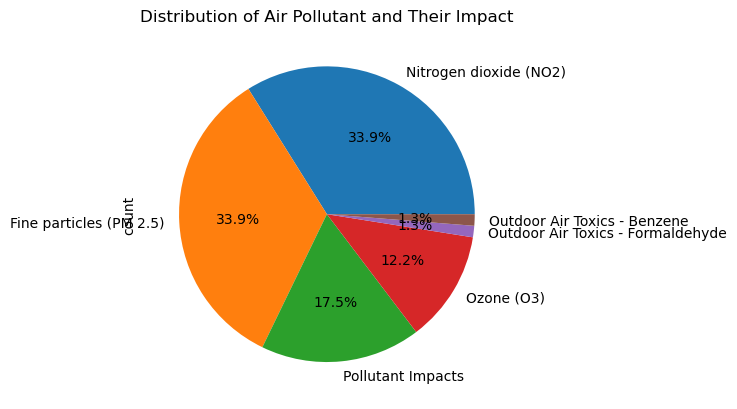

```python
#To create pie chart showing the distribution of pollutant

df['Pollutant_name'].value_counts().plot(kind='pie', autopct='%1.1f%%', startangle=360)
plt.title('Distribution of Air Pollutant and Their Impact')
plt.show()
```

```python
#To get the value counts of the different boroughs
df['Borough_name'].value_counts()
```

```
Borough_name
Manhattan        4092
Brooklyn         4010
Queens           3876
Bronx            3008
Staten_island    1232
Name: count, dtype: int64
```

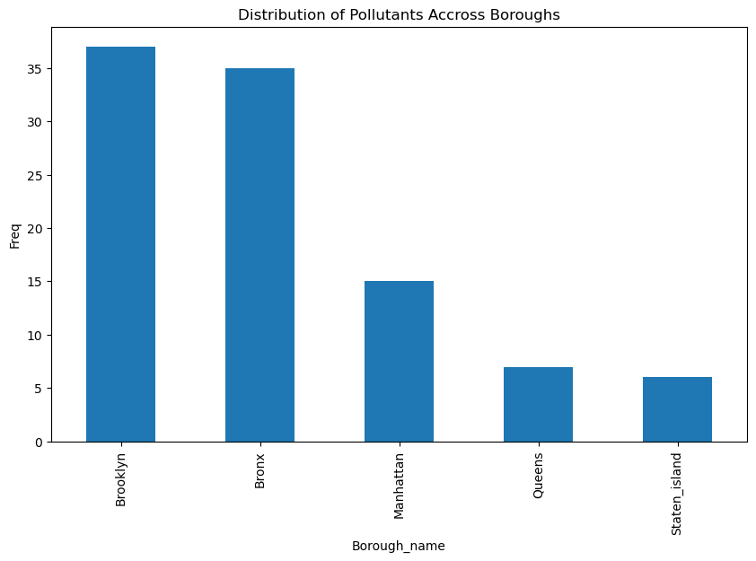

```python
#plotting bar chart to show the pollutant distribution accross boroughs
plt.figure(figsize=(10,6))
df['Borough_name'][:100].value_counts().plot(kind="bar")  # the [:100] helps to reduce the size
plt.title("Distribution of Pollutants Accross Boroughs")
plt.xlabel("Borough_name")
plt.ylabel("Freq")
plt.xticks(rotation=90)
plt.show()
```

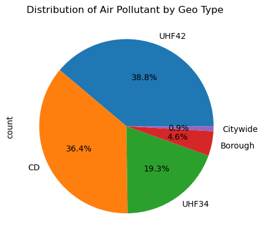

```python
#To create pie chart showing distribution of air pollutant by Geo Type

df['Geo Type Name'].value_counts().plot(kind='pie', autopct='%1.1f%%', startangle=360)
plt.title('Distribution of Air Pollutant by Geo Type ')
plt.show()
```

# Insights:

The chart of distribution of pollutant shows that Nitrogen dioxide (NO2) and Fine Particle (PM2.5) are the major pollutants causing air pollution in New York geographical area.

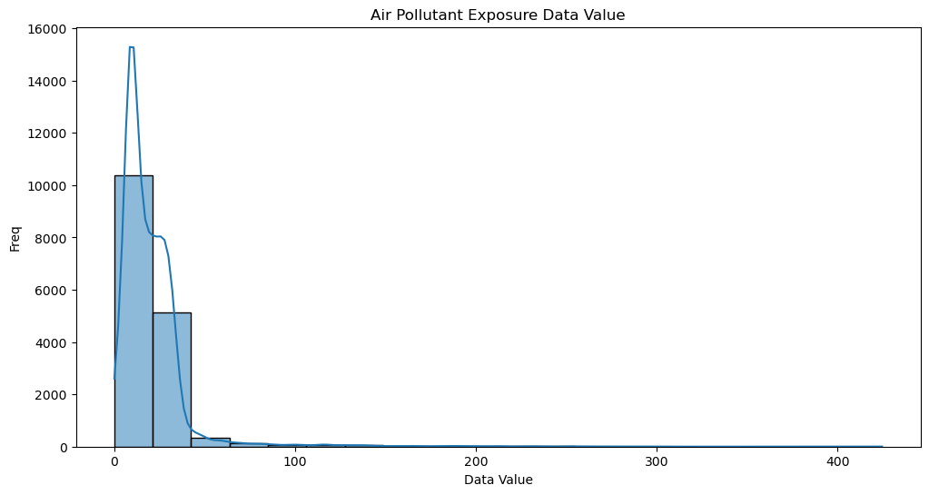

```python
#Using histogram plot for the data value variable
#kde measures the probability density ditribution of the variable
#bins is used to increase the size of the bar/plot
plt.figure(figsize=(12,6))
sns.histplot(df['Data Value'], bins=20, kde=True)
plt.title("Air Pollutant Exposure Data Value")
plt.xlabel("Data Value")
plt.ylabel("Freq")
plt.show()
```

# Insight:

The chart of air pollutants exposure data value shows that most mean data value of all pollutants range between 0 - 50 mean values in New York geographical area.

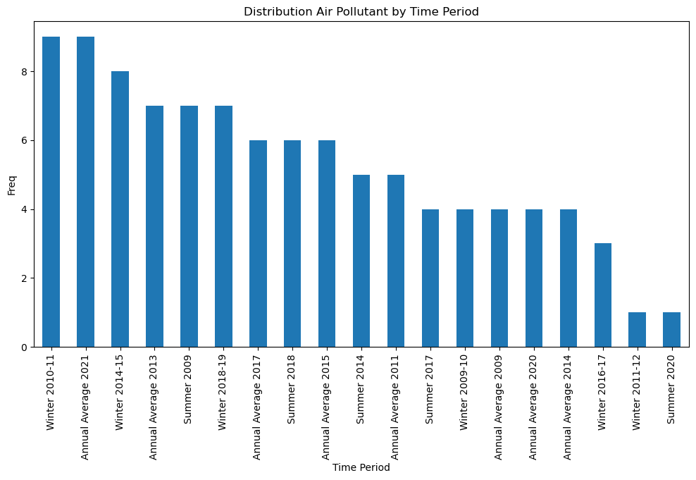

```python
#ploting using bar chart
plt.figure(figsize=(12,6))
df['Time Period'][:100].value_counts().plot(kind="bar")  # the [:100] helps to reduce the size
plt.title("Distribution Air Pollutant by Time Period")
plt.xlabel("Time Period")
plt.ylabel("Freq")
plt.xticks(rotation=90)
plt.show()
```